# IODS course project

Teemu Pekkarinen 014451658

# Introduction to Open Data Science - Course Project

# About the Project

Introduction to Open Data Science. Happy to learn to connect Git and R even though the content of data analysis is *familiar* to me. I’ve used R MarkDown before and found it useful. In addition I’ve used Git before on [Tietokantojen Perusteet](https://github.com/teemupek/Tikape_Chat.git) course. However, it’s been a long time so recalling things is needed. Here’s the [link](https://github.com/teemupek/IODS-project.git) to my IODS GitHub repository.

Today is the following day.

```
## [1] "Mon Nov  2 21:10:28 2020"
```

## Reminders

I wanted to remind me what I’ve done last time with R MarkDown. I found a nice data on **exchange and forward rates**. I make a table and a graph of Sterling/EUR exchange rate. I uploaded `forward2.dat` to git repository and I call my data set from there in order to plot the rate. I hide the R code to make the outcome more readable.

### Table of the exchange and forward rates

|  | EXUSBP | EXUSEUR | EXEURBP | F1USBP | F1USEUR | F1EURBP | F3USBP | F3USEUR | F3EURBP |
| --- | --- | --- | --- | --- | --- | --- | --- | --- | --- |
|  | Min. :1.073 | Min. :0.5827 | Min. :0.3567 | Min. :1.067 | Min. :0.5873 | Min. :0.3588 | Min. :1.061 | Min. :0.5941 | Min. :0.3624 |
|  | 1st Qu.:1.507 | 1st Qu.:0.8876 | 1st Qu.:0.4855 | 1st Qu.:1.504 | 1st Qu.:0.8885 | 1st Qu.:0.4845 | 1st Qu.:1.501 | 1st Qu.:0.8926 | 1st Qu.:0.4841 |
|  | Median :1.617 | Median :1.0738 | Median :0.5598 | Median :1.616 | Median :1.0774 | Median :0.5589 | Median :1.609 | Median :1.0855 | Median :0.5588 |
|  | Mean :1.665 | Mean :1.0416 | Mean :0.6213 | Mean :1.663 | Mean :1.0447 | Mean :0.6203 | Mean :1.658 | Mean :1.0503 | Mean :0.6184 |
|  | 3rd Qu.:1.756 | 3rd Qu.:1.1741 | 3rd Qu.:0.7107 | 3rd Qu.:1.753 | 3rd Qu.:1.1778 | 3rd Qu.:0.7091 | 3rd Qu.:1.748 | 3rd Qu.:1.1819 | 3rd Qu.:0.7051 |
|  | Max. :2.443 | Max. :1.4222 | Max. :1.6002 | Max. :2.441 | Max. :1.4240 | Max. :1.5954 | Max. :2.433 | Max. :1.4278 | Max. :1.5863 |

### Graph of the GBP/EUR exchange rate.

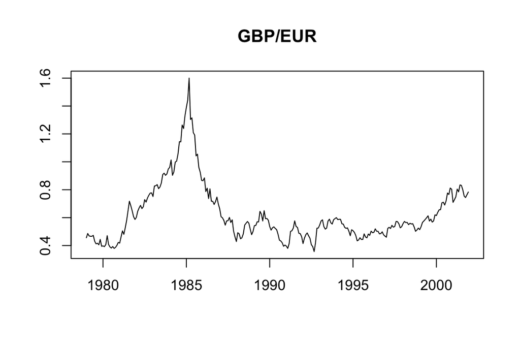

## Latex

I’m happy to see that R MarkDown is linked to LaTeX syntax! Here’s a maximization problem from my current research on the optimal mechanism design with enforcement:
$$\begin{align}
\max_{r(\cdot),t(\cdot),m(\cdot)} \mathbb{E} \left[ t(\theta) - K m(\theta) \right]\label{OBJ} \tag{MAX}
\end{align}$$
subject to
$$\begin{align}
&t(\theta) = \theta r(\theta) - V(\underline{\theta}) - \int_{\underline{\theta}}^{\theta} \mathcal{I}(s|s)ds \label{TAX} \tag{TAX} \\
&\mathcal{I}(\theta|\theta) \qquad \text{is nondecreasing} \label{IC} \tag{IC} \\
&\mathcal{I}(\theta|\theta) \geq 0 \label{IR} \tag{IR}
\end{align}$$
for all $\theta \in \Theta$ with $\mathcal{I}(\theta|\theta):=r(\theta) - m(\theta) \varphi$.

# Analysis

Today is

```
## [1] "Mon Nov  2 21:10:30 2020"
```

In this week we learn how to create data and analyse it. We read the data from the given [URL](https://www.mv.helsinki.fi/home/kvehkala/JYTmooc/JYTOPKYS2-data.txt). The meta descriptions can be found from [here](https://www.mv.helsinki.fi/home/kvehkala/JYTmooc/JYTOPKYS2-meta.txt).

The dataset queries the relationship between learning approaches and students’ achievements in an introductory statistics course in Finland. The original data have 183 responders (observations) for 97 questions (variables). For our purposes, we subset the dataset to contain variables gender, age, attitude, deep, stra, surf and points. The variables are either integers or numerics. The [meta-file](https://www.mv.helsinki.fi/home/kvehkala/JYTmooc/JYTOPKYS2-meta.txt) gives the following description for each variable:

Next we omit the observations where the exam points variable is zero. After that we scale variables by the mean – that is, we divide each combination variable by its number of questions asked. So we have 166 observations for 7 variables left.

## Descriptive Analysis

Let us next read the data we created earlier in the data wranling part:

```r
# Read the data
learning2014 <- read.csv("/Users/teemupekkarinen/IODS-project/data/learning2014",row.names = 1)
```

To summarize our dataset’s content we run

```r
# Structure
str(learning2014)
```

```
## 'data.frame':    166 obs. of  7 variables:
##  $ Gender  : int  2 1 2 1 1 2 1 2 1 2 ...
##  $ Age     : int  53 55 49 53 49 38 50 37 37 42 ...
##  $ Attitude: num  3.7 3.1 2.5 3.5 3.7 3.8 3.5 2.9 3.8 2.1 ...
##  $ Deep    : num  3.58 2.92 3.5 3.5 3.67 ...
##  $ Stra    : num  3.38 2.75 3.62 3.12 3.62 ...
##  $ Surf    : num  2.58 3.17 2.25 2.25 2.83 ...
##  $ Points  : int  25 12 24 10 22 21 21 31 24 26 ...
```

```r
# Dimension
dim(learning2014)
```

```
## [1] 166   7
```

That is, we have the information about gender, age, attitude, and three different learning approaches (deep, strategic, and surface) of 166 responders. All of the variables are numeric and the combination variables (attitude, deep, stra, and surf) are means. For more detailed description we run:

```r
# Summary
summary(learning2014)
```

```
##      Gender           Age           Attitude          Deep
##  Min.   :1.000   Min.   :17.00   Min.   :1.400   Min.   :1.583
##  1st Qu.:1.000   1st Qu.:21.00   1st Qu.:2.600   1st Qu.:3.333
##  Median :2.000   Median :22.00   Median :3.200   Median :3.667
##  Mean   :1.663   Mean   :25.51   Mean   :3.143   Mean   :3.680
##  3rd Qu.:2.000   3rd Qu.:27.00   3rd Qu.:3.700   3rd Qu.:4.083
##  Max.   :2.000   Max.   :55.00   Max.   :5.000   Max.   :4.917
##       Stra            Surf           Points
##  Min.   :1.250   Min.   :1.583   Min.   : 7.00
##  1st Qu.:2.625   1st Qu.:2.417   1st Qu.:19.00
##  Median :3.188   Median :2.833   Median :23.00
##  Mean   :3.121   Mean   :2.787   Mean   :22.72
##  3rd Qu.:3.625   3rd Qu.:3.167   3rd Qu.:27.75
##  Max.   :5.000   Max.   :4.333   Max.   :33.00
```

We observe that there are almost twice more female responders than male responders: 56 men and 110 women. The average age of the responders is 26 and the youngest person is 17 years old and the oldest 55 years old. The age distribution is wide but skewed towards young people. As summarize we can say than a typical responder is a young female.

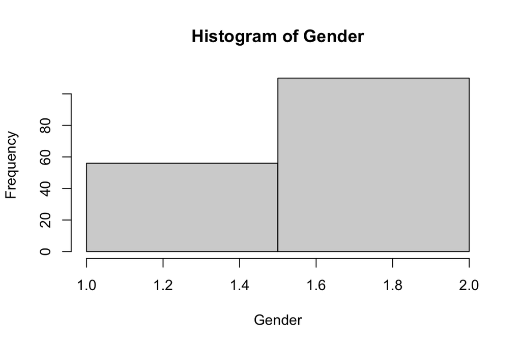

```r
# Histrograms
Gender <- learning2014$Gender
hist(Gender,breaks=2)
```

```r
sum(Gender==1)
```

```
## [1] 56
```

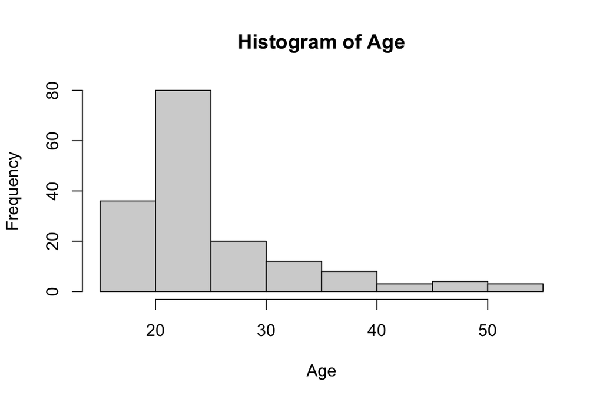

```r
Age <- learning2014$Age
hist(Age)
```

```r
mean(Age)
```

```
## [1] 25.51205
```

```r
var(Age)
```

```
## [1] 60.31198
```

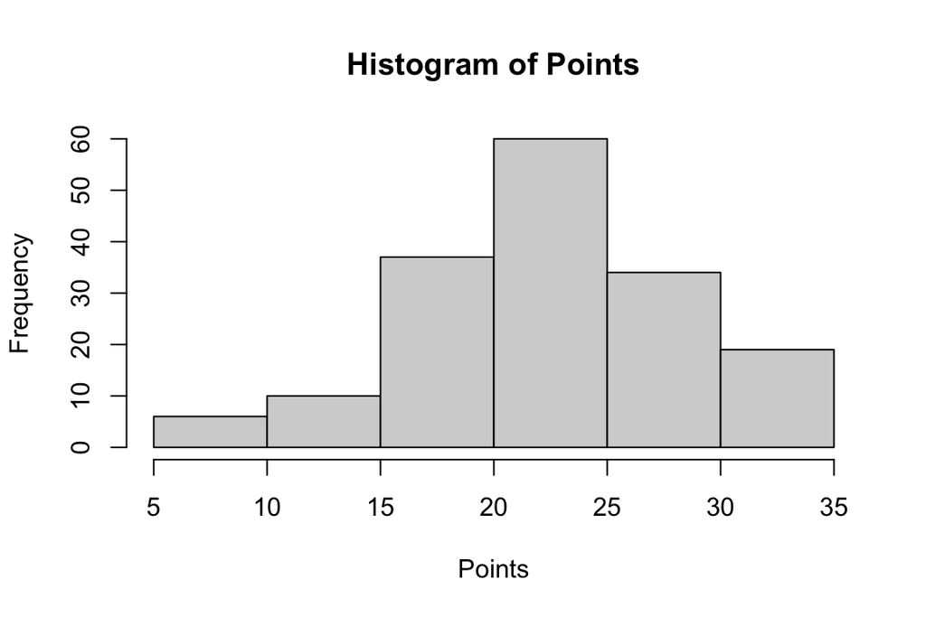

```r
# Histrograms
Points <- learning2014$Points
hist(Points)
```

However, when we compare the points between men and female, we observe that the mean of exam points for men is slightly greater than for women. There are even more men with score 30 or 31 than women.

```r
# Package
library(ggplot2)

# Histrograms
PointsMale <- learning2014$Points[Gender==1]
mean(PointsMale)
```

```
## [1] 23.48214
```

```r
PointsFemale <- learning2014$Points[Gender==2]
mean(PointsFemale)
```

```
## [1] 22.32727
```

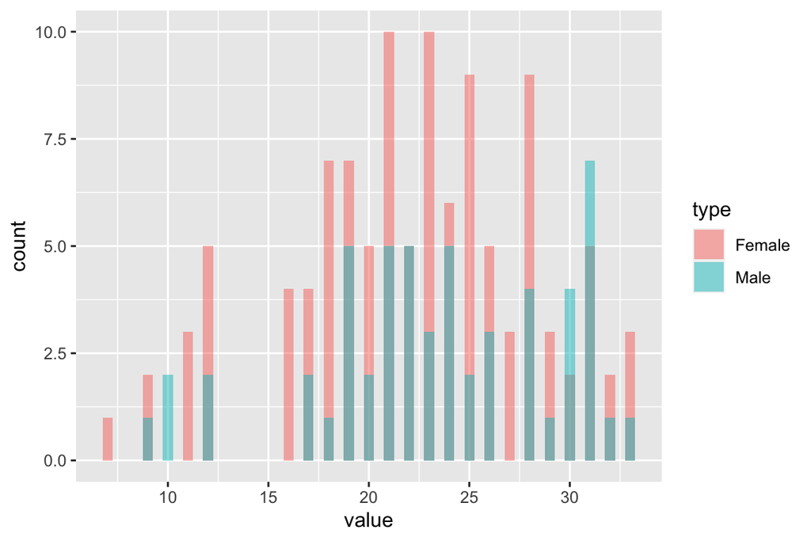

```r
data <- data.frame(
  type = c( rep("Male", 56), rep("Female", 110) ),
  value = c(PointsMale, PointsFemale)
)
ggplot(data, aes(x=value, fill=type)) +
    geom_histogram(binwidth=.5, alpha=.5, position="identity")
```

The mean of attitude, 3.14, is almost neutral 3. That is, on average responders have a bit positive attitude towards statistics. Also attitude is nearly normally distributed. Male responders have more positive attitude than female.

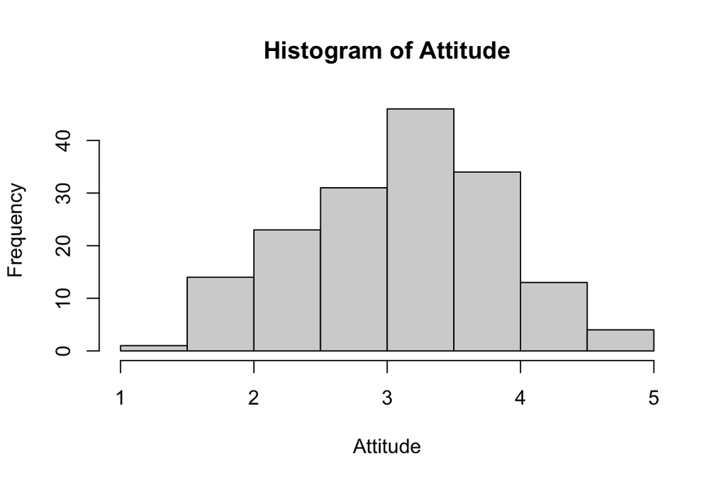

```r
# Histrograms
Attitude <- learning2014$Attitude
hist(Attitude)
```

```r
AttitudeMale <- learning2014$Attitude[Gender==1]
mean(PointsMale)
```

```
## [1] 23.48214
```

```r
AttitudeFemale <- learning2014$Attitude[Gender==2]
mean(PointsFemale)
```

```
## [1] 22.32727
```

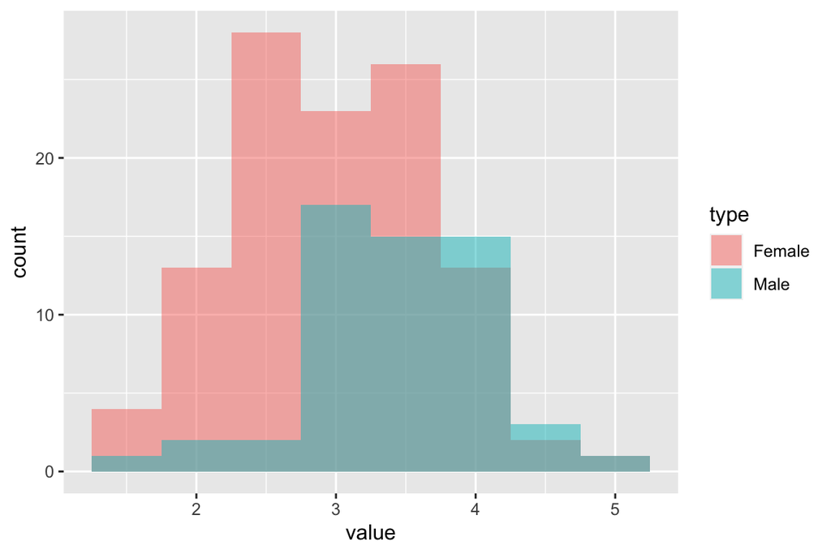

```r
data <- data.frame(
  type = c( rep("Male", 56), rep("Female", 110) ),
  value = c(AttitudeMale, AttitudeFemale)
)
ggplot(data, aes(x=value, fill=type)) +
    geom_histogram(binwidth=.5, alpha=.5, position="identity")
```

The minority prefers surface learning approach to learning in the statistics course, whereas the majority prefers the methods of deep learning. Moreover, the greatest variation in learning methods is in strategic learning. Deep and surface learning is almost identically distributed expect deep learning has a greater mean.

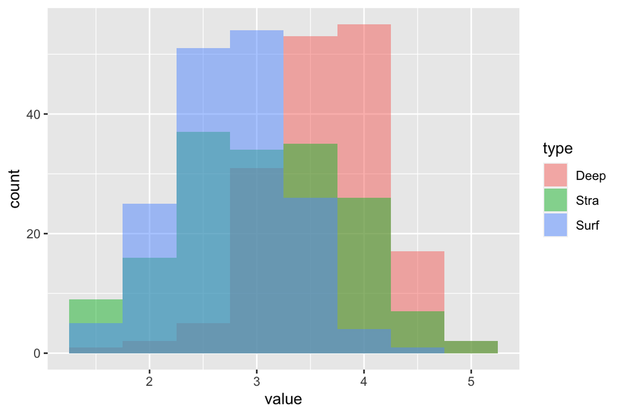

```r
# Package
library(ggplot2)

# Histrograms
Deep <- learning2014$Deep
Stra <- learning2014$Stra
Surf <- learning2014$Surf
data <- data.frame(
  type = c( rep("Deep", 166), rep("Stra", 166), rep("Surf", 166) ),
  value = c(Deep, Stra, Surf)
)
ggplot(data, aes(x=value, fill=type)) +
    geom_histogram(binwidth=.5, alpha=.5, position="identity")
```

There is no much difference between genders in learning methods; the distributions between male and female responders are almost indentically distributed.

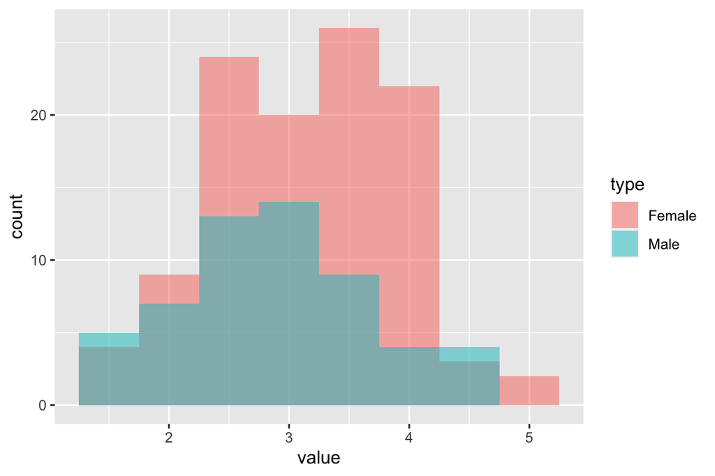

```r
# Histrograms

# Strategic Learning
StraMale <- learning2014$Stra[Gender==1]
StraFemale <- learning2014$Stra[Gender==2]
data <- data.frame(
  type = c( rep("Male", 56), rep("Female", 110) ),
  value = c(StraMale, StraFemale)
)
ggplot(data, aes(x=value, fill=type)) +
    geom_histogram(binwidth=.5, alpha=.5, position="identity")
```

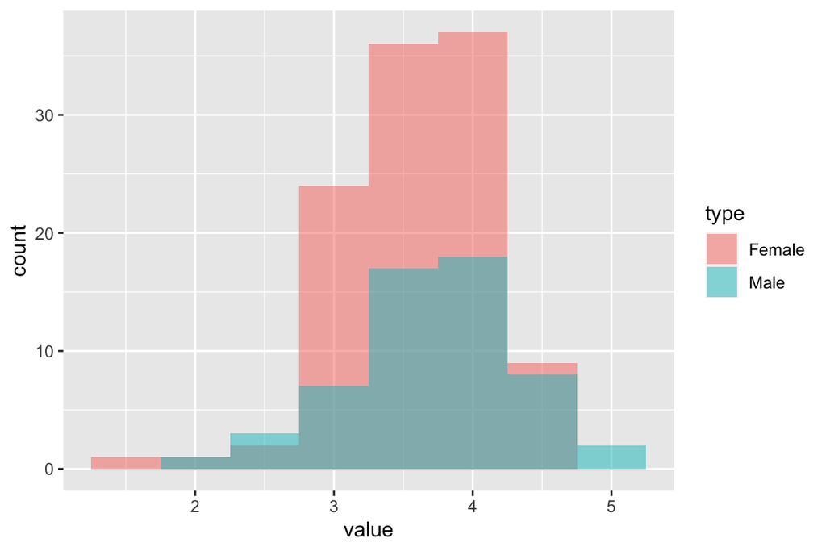

```r
# Deep Learning
DeepMale <- learning2014$Deep[Gender==1]
DeepFemale <- learning2014$Deep[Gender==2]
data <- data.frame(
  type = c( rep("Male", 56), rep("Female", 110) ),
  value = c(DeepMale, DeepFemale)
)
ggplot(data, aes(x=value, fill=type)) +
    geom_histogram(binwidth=.5, alpha=.5, position="identity")
```

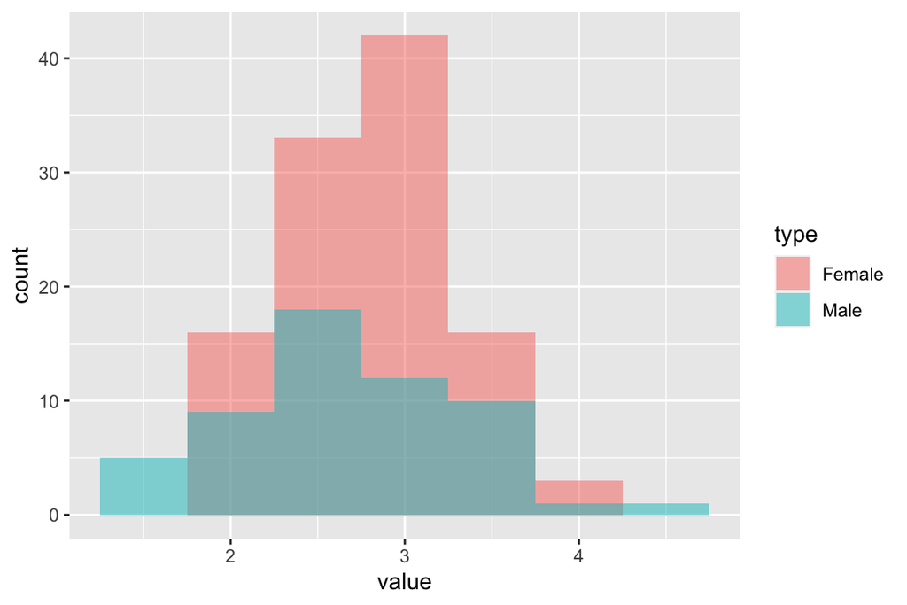

```r
# Surface Learning
SurfMale <- learning2014$Surf[Gender==1]
SurfFemale <- learning2014$Surf[Gender==2]
data <- data.frame(
  type = c( rep("Male", 56), rep("Female", 110) ),
  value = c(SurfMale, SurfFemale)
)
ggplot(data, aes(x=value, fill=type)) +
    geom_histogram(binwidth=.5, alpha=.5, position="identity")
```

## Regressions

Next we run regressions where exam points is our dependent variable. Let us first look at the correlations between exam points and the explanatory variables.

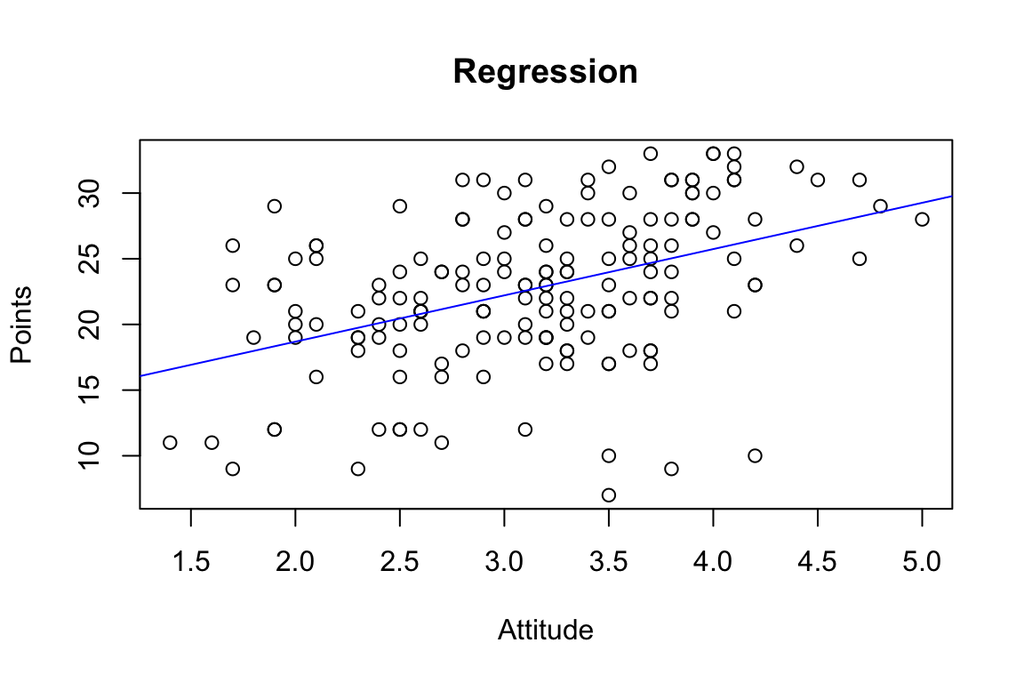

```
## integer(0)
```

```r
plot(Attitude, Points, main = "Regression",
     xlab = "Attitude", ylab = "Points") + abline(lm(Points~Attitude), col = "blue")
```

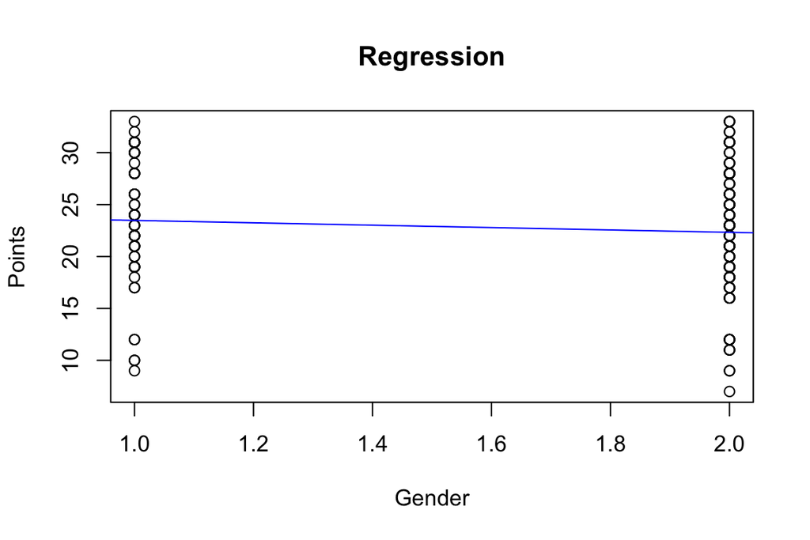

```
## integer(0)
```

```r
plot(Gender, Points, main = "Regression",
     xlab = "Gender", ylab = "Points") + abline(lm(Points~Gender), col = "blue")
```

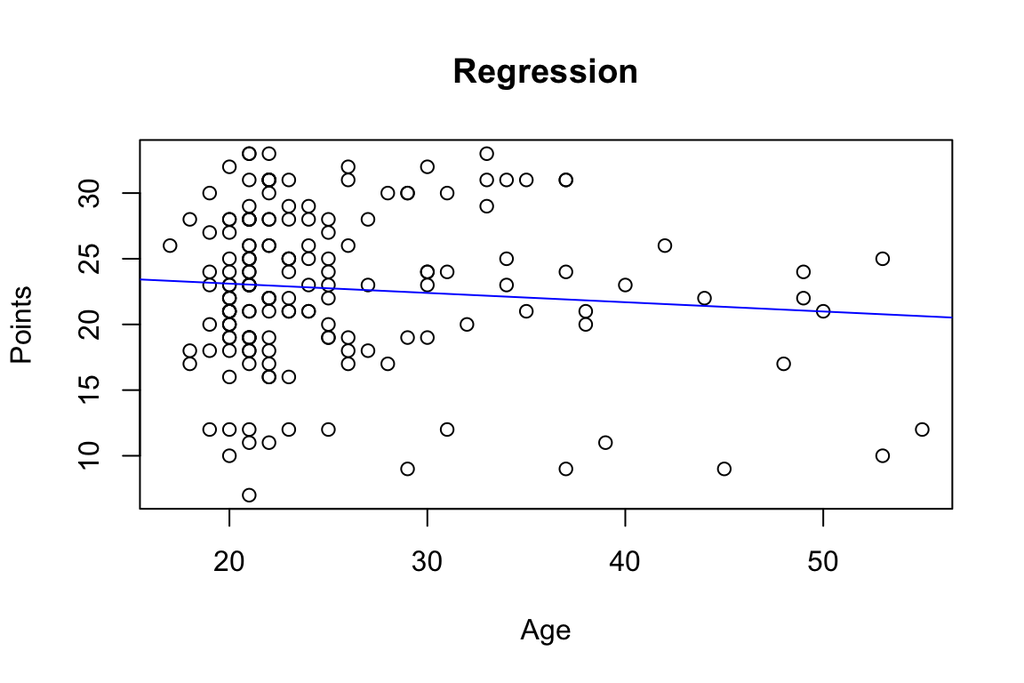

```
## integer(0)
```

```r
plot(Age, Points, main = "Regression",
     xlab = "Age", ylab = "Points") + abline(lm(Points~Age), col = "blue")
```

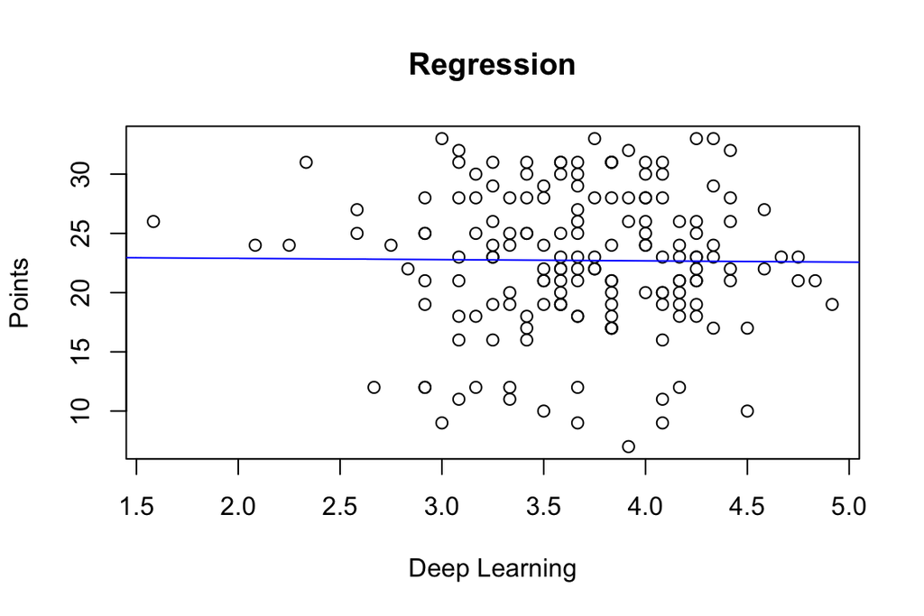

```
## integer(0)
```

```r
plot(Deep, Points, main = "Regression",
     xlab = "Deep Learning", ylab = "Points") + abline(lm(Points~Deep), col = "blue")
```

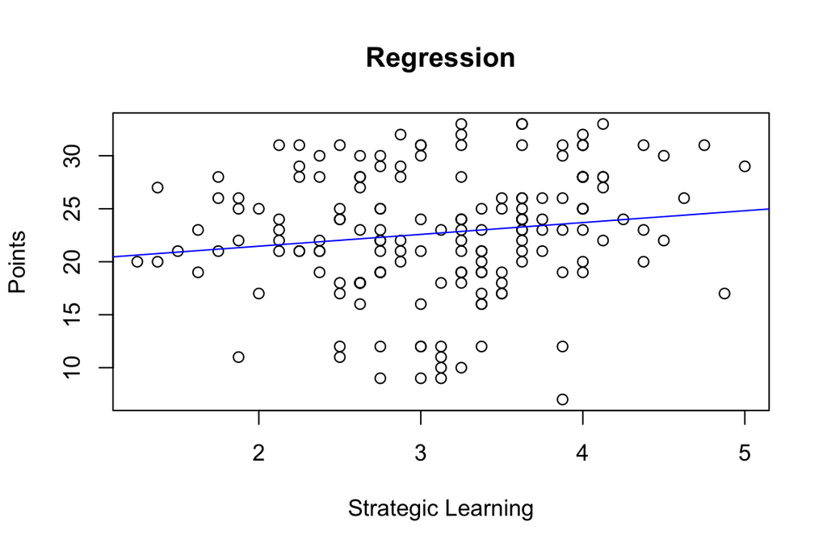

```
## integer(0)
```

```r
plot(Stra, Points, main = "Regression",
     xlab = "Strategic Learning", ylab = "Points") + abline(lm(Points~Stra), col = "blue")
```

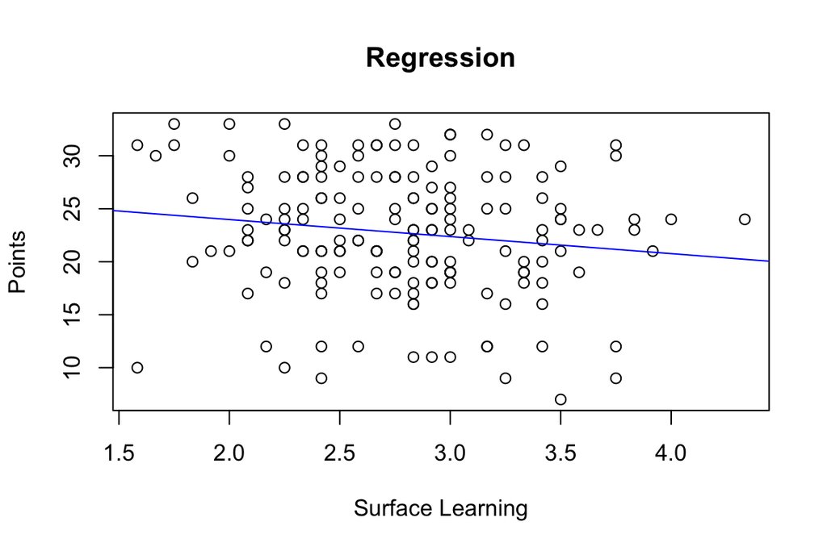

```
## integer(0)
```

```r
plot(Surf, Points, main = "Regression",
     xlab = "Surface Learning", ylab = "Points") + abline(lm(Points~Surf), col = "blue")
```

```r
cov(learning2014)
```

```
##               Gender        Age    Attitude        Deep        Stra        Surf
## Gender    0.22489960 -0.4383352 -0.10184739 -0.01526713  0.05326762  0.02826457
## Age      -0.43833516 60.3119752  0.12584520  0.10792260  0.61406079 -0.58075332
## Attitude -0.10184739  0.1258452  0.53276561  0.04458987  0.03478322 -0.06776013
## Deep     -0.01526713  0.1079226  0.04458987  0.30706766  0.04127419 -0.09489017
## Stra      0.05326762  0.6140608  0.03478322  0.04127419  0.59572437 -0.06570525
## Surf      0.02826457 -0.5807533 -0.06776013 -0.09489017 -0.06570525  0.27967222
## Points   -0.25972983 -4.2662651  1.87824388 -0.03315078  0.66483662 -0.45002434
##               Points
## Gender   -0.25972983
## Age      -4.26626506
## Attitude  1.87824388
## Deep     -0.03315078
## Stra      0.66483662
## Surf     -0.45002434
## Points   34.74965316
```

From the single regressions and the covariance matrix we observe that there is negative correlation between points and gender, age, deep learning and surface learning. That is, what we already observed, men were doing better in the course than women. Moreover, it seems to be so that younger students got better exam results than the older participants. Strategic learning was the only method that has positive correlation between exam results. There is a big positive correaltion between attitude and points.

Next we choose first gender, attitude and age to regress exam points.

```r
reg <- lm(Points~Gender+Attitude+Age)
summary(reg)
```

```
##
## Call:
## lm(formula = Points ~ Gender + Attitude + Age)
##
## Residuals:
##      Min       1Q   Median       3Q      Max
## -17.4590  -3.3221   0.2186   4.0247  10.4632
##
## Coefficients:
##             Estimate Std. Error t value Pr(>|t|)
## (Intercept) 12.76802    3.17695   4.019 8.93e-05 ***
## Gender       0.33054    0.91934   0.360    0.720
## Attitude     3.60657    0.59322   6.080 8.34e-09 ***
## Age         -0.07586    0.05367  -1.414    0.159
## ---
## Signif. codes:  0 '***' 0.001 '**' 0.01 '*' 0.05 '.' 0.1 ' ' 1
##
## Residual standard error: 5.315 on 162 degrees of freedom
## Multiple R-squared:  0.2018, Adjusted R-squared:  0.187
## F-statistic: 13.65 on 3 and 162 DF,  p-value: 5.536e-08
```

From here we observe that attitude is the only significant explanatory variable by itself. However, by the F-test all three variables are *together* significant explanatories.

Nevertheless, following the instructions we drop off gender variable and run the regression again.

```r
# Regression
reg <- lm(Points~Attitude+Age)
summary(reg)
```

```
##
## Call:
## lm(formula = Points ~ Attitude + Age)
##
## Residuals:
##      Min       1Q   Median       3Q      Max
## -17.3354  -3.3095   0.2625   4.0005  10.4911
##
## Coefficients:
##             Estimate Std. Error t value Pr(>|t|)
## (Intercept) 13.57244    2.24943   6.034 1.04e-08 ***
## Attitude     3.54392    0.56553   6.267 3.17e-09 ***
## Age         -0.07813    0.05315  -1.470    0.144
## ---
## Signif. codes:  0 '***' 0.001 '**' 0.01 '*' 0.05 '.' 0.1 ' ' 1
##
## Residual standard error: 5.301 on 163 degrees of freedom
## Multiple R-squared:  0.2011, Adjusted R-squared:  0.1913
## F-statistic: 20.52 on 2 and 163 DF,  p-value: 1.125e-08
```

Attitude remains to be the strongest predictor. Age is still unsignifant even though together with attitude it is significant (F-test). It turns out, after trying all possible combinations of explanatory variables, only regressing with attitude we get 5 % significant level of *all* regressors. We thus lastly regress only with attitude and get the following.

```r
reg <- lm(Points~Attitude)
summary(reg)
```

```
##
## Call:
## lm(formula = Points ~ Attitude)
##
## Residuals:
##      Min       1Q   Median       3Q      Max
## -16.9763  -3.2119   0.4339   4.1534  10.6645
##
## Coefficients:
##             Estimate Std. Error t value Pr(>|t|)
## (Intercept)  11.6372     1.8303   6.358 1.95e-09 ***
## Attitude      3.5255     0.5674   6.214 4.12e-09 ***
## ---
## Signif. codes:  0 '***' 0.001 '**' 0.01 '*' 0.05 '.' 0.1 ' ' 1
##
## Residual standard error: 5.32 on 164 degrees of freedom
## Multiple R-squared:  0.1906, Adjusted R-squared:  0.1856
## F-statistic: 38.61 on 1 and 164 DF,  p-value: 4.119e-09
```

From the summary we observe that the intercept term is positive and significant: 11.63 with standard error of 1.83. This is the test score if attitude was “zero”. Each unit jump in attitution increases (not causal) exam results by 3.5 points. Hence, with maximum attitude our model predicts that the test result is $11.63 + 5 * 3.5 = 29$ points.

We observe also that R-squared decreases a little everytime we omit an explanatory variable from the regression. R-squared is the measure that represents the proportion of the variance for the dependent variable that is explained by explanatory variables. The adjusted R-squared is a modified version of R-squared that has been adjusted for the number of predictors in the model.

Lastly we plot the regression diagnostic plots: Residuals vs Fitted values, Normal QQ-plot and Residuals vs Leverage.

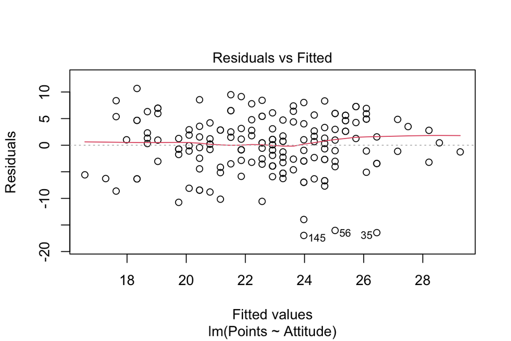

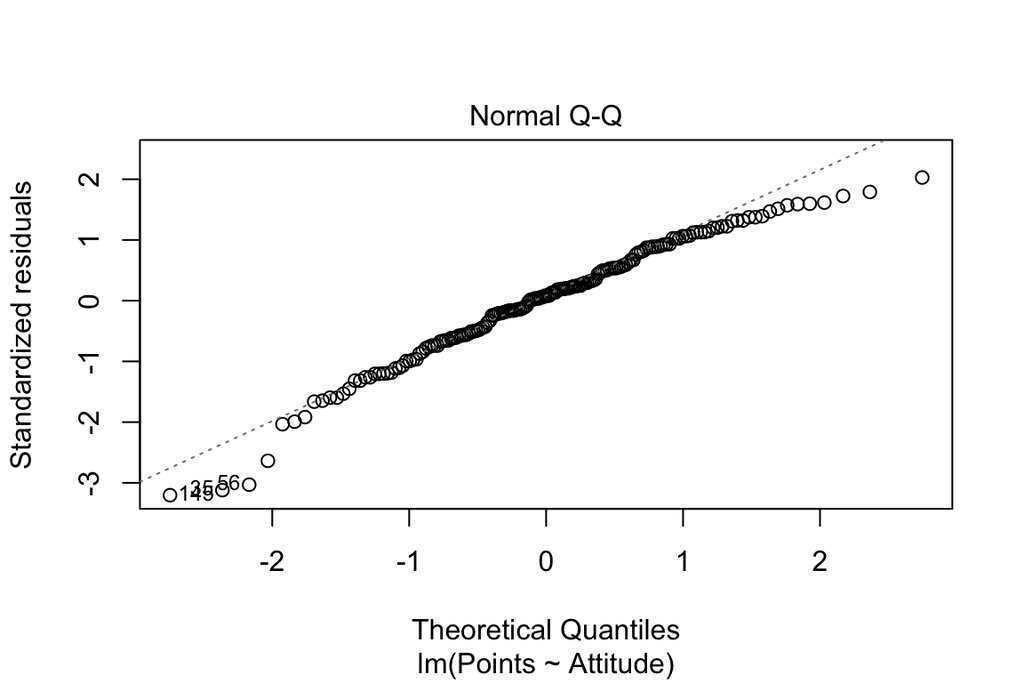

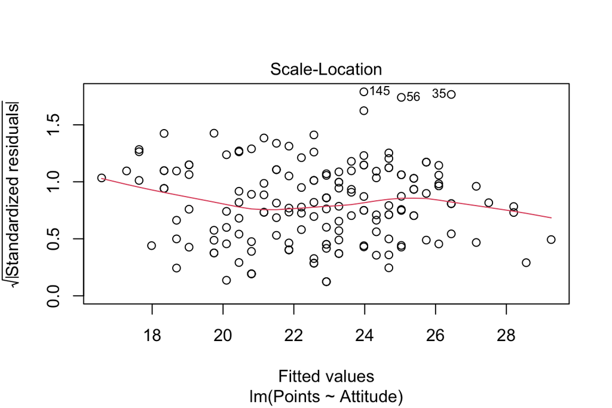

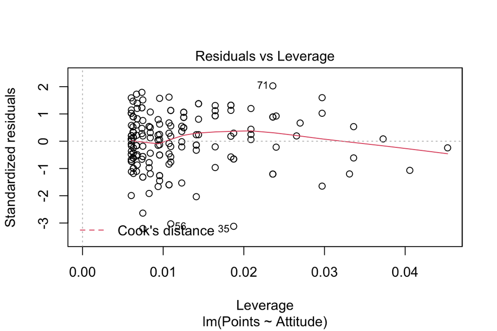

```r
plot(reg)
```

Residuals vs Fitted values figure is a simple scatterplot between residuals and predicted values. It should look more or less random, which is roughly the case in our analysis. The red line is not exactly zero all the time, which is a sign of that the residuals may have a little positive predictive power (omitted variable bias).

The Normal QQ plot helps us to assess whether the residuals are roughly normally distributed. In our cases the tails scarper from the diagonal which may imply that we have some problems with assumption of normally distributed error terms. Probably some t-distribution could be better.

The last plot for the residuals vs leverage (Cook’s distance) tells us which points have the greatest influence on the regression (leverage points). It turns out that points 35, 56, and 71 have the strongest effects on the dependent variable.

## Causal Inference

For the causal inference we need to have very strong assumptions.

Before going to the assumptions, we introduce the vector and matrix notation. Define K-dimensional (column) vectors $\boldsymbol{x}_i$ and $\boldsymbol{\beta}$ as

$$\underset{(K \times 1)}{\boldsymbol{x}_i} =
\begin{pmatrix}
x_{i1} \\ x_{i2} \\ \vdots \\ x_{iK}
\end{pmatrix},
\underset{(K \times 1)}{\boldsymbol{\beta}} =
\begin{pmatrix}
\beta_{1} \\ \beta_{2} \\ \vdots \\ \beta_{K}
\end{pmatrix}.$$
Also define
$$\underset{(n \times 1)}{\boldsymbol{y}} =
\begin{pmatrix}
y_{1} \\ \vdots \\ y_{n}
\end{pmatrix},
\underset{(n \times 1)}{\boldsymbol{\varepsilon}} =
\begin{pmatrix}
\varepsilon_{1} \\ \vdots \\ \varepsilon_{n}
\end{pmatrix},
\underset{(n \times K)}{\boldsymbol{X}} =
\begin{pmatrix}
\boldsymbol{x}'_{1} \\ \vdots \\ \boldsymbol{x}'_{n}
\end{pmatrix} =
\begin{pmatrix}
x_{11} & \dots & x_{1K} \\
\vdots & \ddots & \vdots \\
x_{n1} & \dots & x_{nK}
\end{pmatrix}.$$
Scalar quantities will be given in normal font $x$, vector quantities in bold lowercase $\boldsymbol{x}$, and all vectors will be presumed to be column vectors. Matrix quantities will be in bold uppercase $\boldsymbol{X}$. The transpose of a matrix is denoted by either $\boldsymbol{X}'$ or $\boldsymbol{X}^T$.

Using the matrix notation, the assumptions for the causal inference are the following

Assumption 1.1 (linearity):
$$\underset{(n \times 1)}{\boldsymbol{y}} =
\underset{\underbrace{(n \times K)(K \times 1)}_{(n \times 1)}}{\boldsymbol{X} \: \: \: \boldsymbol{\beta}} + \underset{(n \times 1)}{\boldsymbol{\varepsilon}}.$$

Assumption 1.2 (strict exogeneity):
$$\mathbb{E}(\varepsilon_{i}|\boldsymbol{X}) = 0 \: \: \: (i = 1, 2, \dots, n).$$

Assumption 1.3 (no multicollinearity): The rank of the $n \times K$ data matrix, $\boldsymbol{X}$, is $K$ with probability 1.

Assumption 1.4 (spherical error variance):
$$(\text{homoskedasticity}) \: \: \mathbb{E}(\varepsilon_{i}^2|\boldsymbol{X}) = \sigma^2 > 0 \: \: \: (i = 1, 2, \dots, n),$$
$$(\text{no correlation between observations}) \: \: \: \mathbb{E}(\varepsilon_{i}\varepsilon_{j}|\boldsymbol{X}) = 0 \: \: \: (i, j = 1, 2, \dots, n; i \neq j).$$

Even though our regression diagnostic plots are promising, I would not make any kind of causal interpretations from our model.

(more chapters to be added similarly as we proceed with the course!)